# final_draft_12_6_2

Data Sets Used in this project [NBA Stats](https://www.kaggle.com/datasets/sumitrodatta/nba-aba-baa-stats?select=Team+Summaries.csv), [NBA Draft Data](https://www.kaggle.com/datasets/mattop/nba-draft-basketball-player-data-19892021), [College Player Stats](https://www.kaggle.com/datasets/adityak2003/college-basketball-players-20092021?select=CollegeBasketballPlayers2009-2021.csv) Leave Open for More Data Sets

## The NBA Draft. A chance for change

Throughout all of sports, a draft is one of the most important moments of the year. It gives the worst teams of their respective league the chance to choose the best avaliable prospects to play for their respective francise. Instead of the player choosing where they want to play like in free agency, the organization chooses the players they believe has the best odds of helping their organization win, and then that player must play for that organization until they are allowed to enter free agency a couple of years later. The draft brings these organizations a choice, like what player we should draft, what schools have the best players and much more. In this project, I hope to uncover some of the mysteries of the draft, and try to find out what sort of player should be selected in next years NBA draft

```python
import pandas as pd
import numpy as np
import matplotlib.pyplot as plt
import seaborn as sb
!pip install plotnine
from plotnine import *
```

```python
draft_info = pd.read_csv('nbaplayersdraft.csv')
#draft_info.head()
```

[output not shown]

5 rows × 24 columns

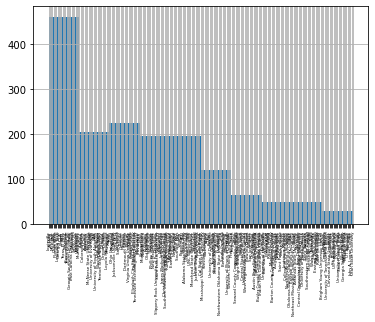

```python
# Simple chart used to see which colleges have the most amount of drafted players.
draft_info['college'].hist(xrot=90, xlabelsize=4)
```

```python
# Data Frame that is used to get an understanding as to what schools have the most and least amount of drafted players since 1989
draft_info.groupby(['college']).count().sort_values(['year'])
```

| college | id | year | rank | overall_pick | team | player | years_active | games | minutes_played | points | ... | 3_point_percentage | free_throw_percentage | average_minutes_played | points_per_game | average_total_rebounds | average_assists | win_shares | win_shares_per_48_minutes | box_plus_minus | value_over_replacement |
| --- | --- | --- | --- | --- | --- | --- | --- | --- | --- | --- | --- | --- | --- | --- | --- | --- | --- | --- | --- | --- | --- |
| Yale | 1 | 1 | 1 | 1 | 1 | 1 | 1 | 1 | 1 | 1 | ... | 1 | 1 | 1 | 1 | 1 | 1 | 1 | 1 | 1 | 1 |
| Miami University | 1 | 1 | 1 | 1 | 1 | 1 | 1 | 1 | 1 | 1 | ... | 1 | 1 | 1 | 1 | 1 | 1 | 1 | 1 | 1 | 1 |
| UNC Wilmington | 1 | 1 | 1 | 1 | 1 | 1 | 1 | 1 | 1 | 1 | ... | 1 | 1 | 1 | 1 | 1 | 1 | 1 | 1 | 1 | 1 |
| UT Arlington | 1 | 1 | 1 | 1 | 1 | 1 | 1 | 1 | 1 | 1 | ... | 1 | 0 | 1 | 1 | 1 | 1 | 1 | 1 | 1 | 1 |
| McNeese State University | 1 | 1 | 1 | 1 | 1 | 1 | 0 | 0 | 0 | 0 | ... | 0 | 0 | 0 | 0 | 0 | 0 | 0 | 0 | 0 | 0 |
| ... | ... | ... | ... | ... | ... | ... | ... | ... | ... | ... | ... | ... | ... | ... | ... | ... | ... | ... | ... | ... | ... |
| UCLA | 42 | 42 | 42 | 42 | 42 | 42 | 41 | 41 | 41 | 41 | ... | 39 | 41 | 41 | 41 | 41 | 41 | 41 | 41 | 41 | 41 |
| UNC | 43 | 43 | 43 | 43 | 43 | 43 | 40 | 40 | 40 | 40 | ... | 40 | 40 | 40 | 40 | 40 | 40 | 40 | 40 | 40 | 40 |
| Arizona | 43 | 43 | 43 | 43 | 43 | 43 | 41 | 41 | 41 | 41 | ... | 37 | 38 | 41 | 41 | 41 | 41 | 41 | 41 | 41 | 41 |
| Duke | 57 | 57 | 57 | 57 | 57 | 57 | 53 | 53 | 53 | 53 | ... | 52 | 53 | 53 | 53 | 53 | 53 | 53 | 53 | 53 | 53 |
| Kentucky | 58 | 58 | 58 | 58 | 58 | 58 | 57 | 57 | 57 | 57 | ... | 56 | 57 | 57 | 57 | 57 | 57 | 57 | 57 | 57 | 57 |

237 rows × 23 columns

```python
# This is a data frame that sees what colleges have the highest average minutes in the nba.
colleges = draft_info.groupby(['college'])['average_minutes_played'].mean()
colleges = colleges.to_frame()
colleges = colleges['average_minutes_played'].dropna()
colleges.sort_values()
```

```
college
Toledo                                 1.6
UAB                                    2.5
University of North Dakota             2.5
Tennessee Technological University     3.6
University of North Texas              3.8
                                      ...
Santa Clara                           31.3
Lehigh                                31.6
Butler County Community College       31.9
University of Hartford                32.5
Davidson                              34.3
Name: average_minutes_played, Length: 219, dtype: float64
```

The data frame above can be used to help an NBA scout to figure out what colleges might produce quality players. In the NBA, the longer a player is on the court, the better the player in most cases. This is true with all sports but especially in the NBA where there are only five players on the court at a time. There is a small problem with using this method to try to figure out what college a team should draft from. This data frame uses the average minutes played for each college, which can be suseptiable to outliers and small data sets. For example, it looks like it would be a good idea to draft a player from Lehigh, the only problem is that there has been only one player drafted in school history, CJ McCollum. Since CJ has been the only player drafted from Lehigh, it could make this data frame very hard to use for any form of analysis since it can be swayed by colleges that have only had a couple of players drafted, as compared to bigger schools such as UNC which has had over 40 players drafted since 1989.

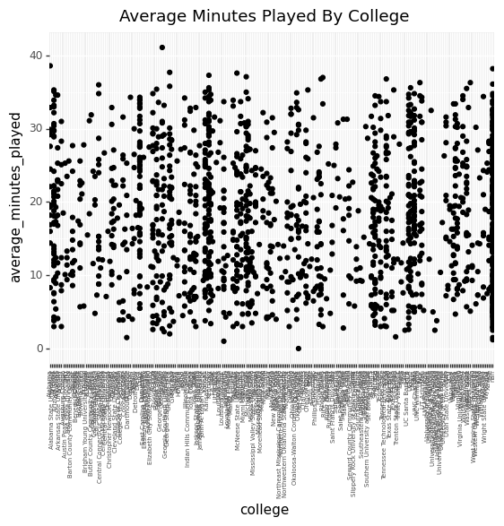

```python
# This is just an exploratory graph to see if any information can be gained from looking at colleges from this data set. Looking at this graph, not really.
flip_xlabels = theme(axis_text_x = element_text(angle=90, hjust=-5, size=5))
ggplot(draft_info, aes(x="college", y="average_minutes_played"))+geom_point() + flip_xlabels + ggtitle("Average Minutes Played By College")
```

# Points Per Game Analysis

```python
# This is a bit of code that creates a data frame that can see the mean points per game by draft position
draft_position = draft_info.groupby(['overall_pick'])['points_per_game'].mean()
draft_position = draft_position.to_frame()
draft_position['position'] = np.arange(1,61,1)
#draft_position['position'] = draft_position['position'].astype(float)
#draft_position.head()
```

[output not shown]

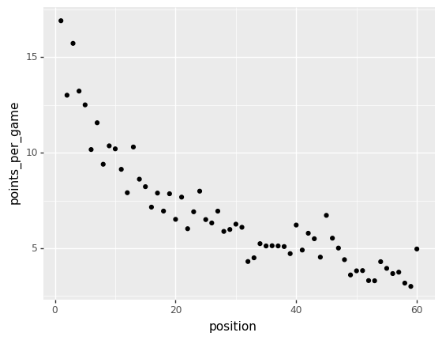

```python
# This is just a simple plot to get an understanding to how the points per game of a player change as the draft position changes. This graph is not meant to be something presented,
# Only for the coder to see the relationship
ggplot(draft_position, aes(x='position', y='points_per_game'))+geom_point()
```

```python
from sklearn.linear_model import LogisticRegression
from sklearn.preprocessing import PolynomialFeatures
from sklearn.linear_model import LinearRegression
```

```python
# This is code that sets up the polynomial regression
x = draft_position.position.values
#x=x.reshape(len(x), 1)
poly = PolynomialFeatures(degree=2, include_bias=True)
poly_features = poly.fit_transform(x.reshape(-1,1))
```

```python
# This block of code is meant to create a polynomial regression between points per game and draft position
poly_reg_model = LinearRegression()
y=draft_position.points_per_game.values
y=y.reshape(len(y), 1)
poly_reg_model.fit(poly_features, y)
y_predicted = poly_reg_model.predict(poly_features)
poly_reg_model.score(poly_features,y)
```

```
0.8834275816000674
```

```python
# This block of code is meant to see if a linear model is a better representation of the data than the polynomial model. Based on the correlation coefficient, the polynomial model
# is a better fit for this dataset.
lin_reg_model = LinearRegression()
x=draft_position.position.values
x=x.reshape(len(x),1)
y=draft_position.points_per_game.values
y=y.reshape(len(y),1)
lin_reg_model.fit(x,y)
lin_reg_model.score(x,y)
```

```
0.7676438265673844
```

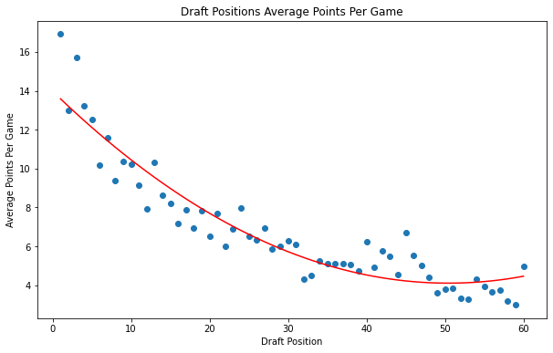

```python
plt.figure(figsize=(10,6))
plt.scatter(draft_position['position'], draft_position['points_per_game'])
plt.plot(x, y_predicted, c="red")
plt.xlabel("Draft Position")
plt.ylabel("Average Points Per Game")
plt.title("Draft Positions Average Points Per Game")
plt.show()
```

[output not shown]

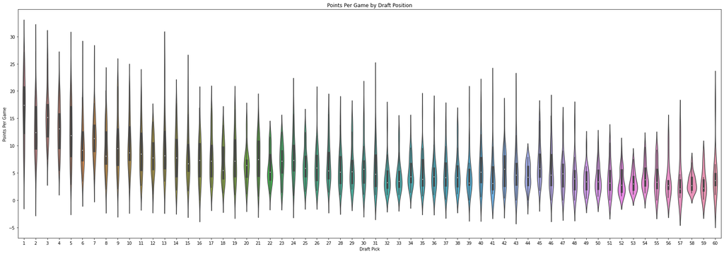

```python
a4_dims = (30, 10)
fig, ax = plt.subplots(figsize=a4_dims)
sb.violinplot(ax=ax, data=draft_info,  x="overall_pick", y="points_per_game").set(title="Points Per Game by Draft Position",xlabel='Draft Pick', ylabel='Points Per Game')
```

This graph gives us another perspective on which draft positions and which ones might be useful. All of the early picks have very wide ranges with a small amount of data gathered around the mean. These early draft picks have a small chance to have incredible scoring averages, but also the same change of having a terrible scoring average as well. It isn't until you get to around pick 30 where you shart to see more of the data around the mean. These picks don't have as much upside as the earlier picks, but there is less of a change they will result in a bust. This is something to consider if you are a general manager for an NBA team.

# Win Shares Analysis

```python
# An advanced stat that can help to determine a players value is win shares
# Add in Years Played as well so we can get the average wins per season a player generates per draft position
win_shares_pos= draft_info.groupby(['overall_pick'])['win_shares'].mean()
avg_years_played = draft_info.groupby(['overall_pick'])['years_active'].mean()
win_shares_pos = win_shares_pos.to_frame()
win_shares_pos['position'] = np.arange(1,61,1)
avg_years_played = avg_years_played.to_frame()
avg_years_played['position'] = np.arange(1,61,1)
#draft_position['position'] = draft_position['position'].astype(float)
win_shares_pos.head()
```

| overall_pick | win_shares | position |
| --- | --- | --- |
| 1 | 61.748485 | 1 |
| 2 | 46.251515 | 2 |
| 3 | 52.778788 | 3 |
| 4 | 48.160606 | 4 |
| 5 | 45.384848 | 5 |

```python
# Creates a data frame that merges win shares and years played to create a new data frame. Also creates a column to get the average win shares by year for each draft position
win_shares_and_years_played = pd.merge(win_shares_pos, avg_years_played,  on="position")
win_shares_and_years_played['win_shares_per_year'] = win_shares_and_years_played['win_shares'] / win_shares_and_years_played['years_active']
win_shares_and_years_played.head()
```

|  | win_shares | position | years_active | win_shares_per_year |
| --- | --- | --- | --- | --- |
| 0 | 61.748485 | 1 | 10.545455 | 5.855460 |
| 1 | 46.251515 | 2 | 10.090909 | 4.583483 |
| 2 | 52.778788 | 3 | 10.363636 | 5.092690 |
| 3 | 48.160606 | 4 | 10.515152 | 4.580115 |
| 4 | 45.384848 | 5 | 10.696970 | 4.242776 |

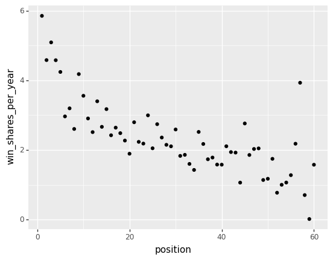

```python
# This is a simple plot to understand how win shares changed by Draft Position
ggplot(win_shares_and_years_played, aes(x='position', y='win_shares_per_year'))+geom_point()
```

```python
# Frame that Does not have the outlier of draft position 57
test_frame = win_shares_and_years_played[win_shares_and_years_played['position'] != 57]
```

```python
# Creates a polynomial model that does better than a linear model.
x = test_frame.position.values
poly = PolynomialFeatures(degree=2, include_bias=True)
poly_features = poly.fit_transform(x.reshape(-1,1))
```

```python
poly_reg_model = LinearRegression()
y= test_frame.win_shares_per_year.values
y= y.reshape(len(y), 1)
poly_reg_model.fit(poly_features, y)
y_predicted = poly_reg_model.predict(poly_features)
poly_reg_model.score(poly_features,y)
```

```
0.7413129399539984
```

```python
import statsmodels.api as sm
import statsmodels.formula.api as smf
```

```python
# This bit of code is to find a linear regression between draft position and win shares per year
mod = smf.ols(formula = 'win_shares_per_year ~ position', data=win_shares_and_years_played)
res = mod.fit()
print(res.summary())
```

```
                             OLS Regression Results
===============================================================================
Dep. Variable:     win_shares_per_year   R-squared:                       0.575
Model:                             OLS   Adj. R-squared:                  0.568
Method:                  Least Squares   F-statistic:                     78.49
Date:                 Tue, 06 Dec 2022   Prob (F-statistic):           2.26e-12
Time:                         16:40:20   Log-Likelihood:                -64.572
No. Observations:                   60   AIC:                             133.1
Df Residuals:                       58   BIC:                             137.3
Df Model:                            1
Covariance Type:             nonrobust
==============================================================================
                 coef    std err          t      P>|t|      [0.025      0.975]
------------------------------------------------------------------------------
Intercept      3.8172      0.189     20.222      0.000       3.439       4.195
position      -0.0477      0.005     -8.860      0.000      -0.058      -0.037
==============================================================================
Omnibus:                       28.367   Durbin-Watson:                   1.322
Prob(Omnibus):                  0.000   Jarque-Bera (JB):               53.010
Skew:                           1.578   Prob(JB):                     3.08e-12
Kurtosis:                       6.353   Cond. No.                         71.1
==============================================================================

Notes:
[1] Standard Errors assume that the covariance matrix of the errors is correctly specified.
```

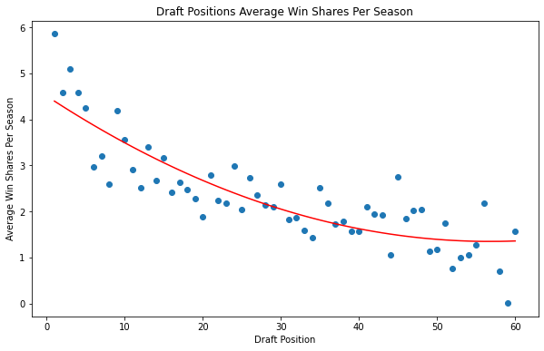

```python
plt.figure(figsize=(10,6))
plt.scatter(test_frame['position'], test_frame['win_shares_per_year'])
plt.plot(x, y_predicted, c="red")
plt.xlabel("Draft Position")
plt.ylabel("Average Win Shares Per Season")
plt.title("Draft Positions Average Win Shares Per Season")
plt.show()
```

To Start off, what are win shares. Win shares is an advanced statistic in basketball that attempts to divvy up credit for a teams success to the individuals on the team. If a player has one win share, then one win for that season can be contributed to solely them. If you look at a couple of games, this statistic is not very helpful, but over a career, it can help to quantify how impactful a basketball player is. For more Info, [Win Shares](https://www.basketball-reference.com/about/ws.html). For a general manager who is drafting a player, it can be helpful to see how many wins a draft position would contribute each year. This could be super helpful as if a team missed the playoffs last year by 3 wins, they would hopefully only need to draft a position that has a win share per season average of over 3 to get into the playoffs. The team might have the 20th pick in the draft, which would not be enough of an increase in games to make the playoffs the next year, so they might want to consider trading up to get a higher pick.

# The Draft By Player Statistics Final Thoughts

After looking at a couple of measurements of player success in the NBA, we found some interesting trends. The first is that there appears to be a polynomial relationship between draft position and player success. This makes sense though, as a player can't have a statistic less than zero. For example, a player can't score less than zero points in a game. Also another factor is that there are only 60 players drafted each year, so the graphs do end without going to zero exactally. But this does bring up an interesting question with drafting and if you should trade up in the draft. It normally would not make sense to trade up from the 20th draft position to the 19th position because the player will only be marginally better on average, and the picks and players you might have to give up would not be worth it. The second interesting trend that I saw was that the third pick was always better than the second pick in terms of statistics. This is really interesting at normally you would think the second pick would be a lot better than the third pick since the graph follows a polynomial relationship, but this is not the case. This might have to do with the nature of the draft. It is hard to pick out players from their time in college and overseas and translate that into success in the NBA. That is why drafting is so hard and the best player in the draft in not always picked first. So what should a general manager do. The small problem we have with the current analysis is that we are only looking at players statistics after they have been drafted, not before. There was no data on a players college statistics or statistics from their previous league (if they played overseas for example). Also another problem we have is we are not looking at the teams these players are being drafted to. Where a player is drafted too is a big factor into their success. For example, James Wiseman was drafted to the Warriors second overall in 2020, but has not gotten a lot of playing time even though he was a second overall pick. This is because the warriors already have a stacked roster with players like Steph Curry, Klay Thompson, and Draymond Green, so there is not a lot of playing time for Wiseman to get on the floor. This has hampered his career statistics and impact on the court but if Wiseman was drafted to a team like the Houston Rockets, who have been one of the worst teams since he was drafted, he might have better career statistics.

# Code for the College Stuff

For the first part of my analysis of college players, I wanted to see If I can fit a model between all of the college statistics of a player for a year and see if they got drafted or not. This could be super helpful as we could learn what sort production a player must have in college to be drafted into the NBA.

```python
college_stats = pd.read_csv("CollegeBasketballPlayers2009-2021.csv")
college_stats.head()
```

|  | player_name | team | conf | GP | Min_per | Ortg | usg | eFG | TS_per | ORB_per | ... | dgbpm | oreb | dreb | treb | ast | stl | blk | pts | Unnamed: 64 | Unnamed: 65 |
| --- | --- | --- | --- | --- | --- | --- | --- | --- | --- | --- | --- | --- | --- | --- | --- | --- | --- | --- | --- | --- | --- |
| 0 | DeAndrae Ross | South Alabama | SB | 26 | 29.5 | 97.3 | 16.6 | 42.5 | 44.43 | 1.6 | ... | -1.941150 | 0.1923 | 0.6154 | 0.8077 | 1.1923 | 0.3462 | 0.0385 | 3.8846 | NaN | 6.22026 |
| 1 | Pooh Williams | Utah St. | WAC | 34 | 60.9 | 108.3 | 14.9 | 52.4 | 54.48 | 3.8 | ... | -0.247934 | 0.6765 | 1.2647 | 1.9412 | 1.8235 | 0.4118 | 0.2353 | 5.9412 | NaN | 3.94375 |
| 2 | Jesus Verdejo | South Florida | BE | 27 | 72.0 | 96.2 | 21.8 | 45.7 | 47.98 | 2.1 | ... | -0.883163 | 0.6296 | 2.3333 | 2.9630 | 1.9630 | 0.4815 | 0.0000 | 12.1852 | NaN | 10.92680 |
| 3 | Mike Hornbuckle | Pepperdine | WCC | 30 | 44.5 | 97.7 | 16.0 | 53.6 | 53.69 | 4.1 | ... | -0.393459 | 0.7000 | 1.4333 | 2.1333 | 1.1000 | 0.5667 | 0.1333 | 4.9333 | NaN | 6.77427 |
| 4 | Anthony Brown | Pacific | BW | 33 | 56.2 | 96.5 | 22.0 | 52.8 | 54.31 | 8.3 | ... | -0.668318 | 1.4242 | 3.3030 | 4.7273 | 0.8485 | 0.4545 | 0.3333 | 7.5758 | NaN | 0.00000 |

5 rows × 66 columns

```python
def wasPicked(x, name, year):
    temp_df = college_stats[college_stats['player_name'] == name]
    max_year = temp_df['year'].max()
    if max_year == year:
        if x == x:
            return True
        return False
    return False
```

```python
# this is used to create a target variable that makes sense to the algorithm. Its just taking if a player got drafted and saying True or False
college_stats["was_picked"] = college_stats.apply(lambda x: wasPicked(x["pick"], x['player_name'], x['year']), axis=1)
college_stats.head()
```

|  | player_name | team | conf | GP | Min_per | Ortg | usg | eFG | TS_per | ORB_per | ... | oreb | dreb | treb | ast | stl | blk | pts | Unnamed: 64 | Unnamed: 65 | was_picked |
| --- | --- | --- | --- | --- | --- | --- | --- | --- | --- | --- | --- | --- | --- | --- | --- | --- | --- | --- | --- | --- | --- |
| 0 | DeAndrae Ross | South Alabama | SB | 26 | 29.5 | 97.3 | 16.6 | 42.5 | 44.43 | 1.6 | ... | 0.1923 | 0.6154 | 0.8077 | 1.1923 | 0.3462 | 0.0385 | 3.8846 | NaN | 6.22026 | False |
| 1 | Pooh Williams | Utah St. | WAC | 34 | 60.9 | 108.3 | 14.9 | 52.4 | 54.48 | 3.8 | ... | 0.6765 | 1.2647 | 1.9412 | 1.8235 | 0.4118 | 0.2353 | 5.9412 | NaN | 3.94375 | False |
| 2 | Jesus Verdejo | South Florida | BE | 27 | 72.0 | 96.2 | 21.8 | 45.7 | 47.98 | 2.1 | ... | 0.6296 | 2.3333 | 2.9630 | 1.9630 | 0.4815 | 0.0000 | 12.1852 | NaN | 10.92680 | False |
| 3 | Mike Hornbuckle | Pepperdine | WCC | 30 | 44.5 | 97.7 | 16.0 | 53.6 | 53.69 | 4.1 | ... | 0.7000 | 1.4333 | 2.1333 | 1.1000 | 0.5667 | 0.1333 | 4.9333 | NaN | 6.77427 | False |
| 4 | Anthony Brown | Pacific | BW | 33 | 56.2 | 96.5 | 22.0 | 52.8 | 54.31 | 8.3 | ... | 1.4242 | 3.3030 | 4.7273 | 0.8485 | 0.4545 | 0.3333 | 7.5758 | NaN | 0.00000 | False |

5 rows × 67 columns

```python
# This drops all of the columns that are missing a lot of data or are text such as school and plyaer name.
college_stats = college_stats.drop(['pick','Unnamed: 64', 'Unnamed: 65', 'player_name', 'team', 'conf', 'yr','ht','num', 'type', 'year', 'pid', 'rimmade','rimmade+rimmiss',
                                   'midmade','midmade+midmiss','rimmade/(rimmade+rimmiss)', 'midmade/(midmade+midmiss)',
                                    'dunksmade','dunksmiss+dunksmade', 'dunksmade/(dunksmade+dunksmiss)'], axis=1)
college_stats = college_stats.dropna(how='all')
college_stats.head()
```

|  | GP | Min_per | Ortg | usg | eFG | TS_per | ORB_per | DRB_per | AST_per | TO_per | ... | ogbpm | dgbpm | oreb | dreb | treb | ast | stl | blk | pts | was_picked |
| --- | --- | --- | --- | --- | --- | --- | --- | --- | --- | --- | --- | --- | --- | --- | --- | --- | --- | --- | --- | --- | --- |
| 0 | 26 | 29.5 | 97.3 | 16.6 | 42.5 | 44.43 | 1.6 | 4.6 | 15.8 | 16.3 | ... | -2.781990 | -1.941150 | 0.1923 | 0.6154 | 0.8077 | 1.1923 | 0.3462 | 0.0385 | 3.8846 | False |
| 1 | 34 | 60.9 | 108.3 | 14.9 | 52.4 | 54.48 | 3.8 | 6.3 | 13.6 | 19.8 | ... | -0.052263 | -0.247934 | 0.6765 | 1.2647 | 1.9412 | 1.8235 | 0.4118 | 0.2353 | 5.9412 | False |
| 2 | 27 | 72.0 | 96.2 | 21.8 | 45.7 | 47.98 | 2.1 | 8.0 | 14.7 | 15.9 | ... | 1.548230 | -0.883163 | 0.6296 | 2.3333 | 2.9630 | 1.9630 | 0.4815 | 0.0000 | 12.1852 | False |
| 3 | 30 | 44.5 | 97.7 | 16.0 | 53.6 | 53.69 | 4.1 | 9.4 | 13.7 | 23.8 | ... | -0.342775 | -0.393459 | 0.7000 | 1.4333 | 2.1333 | 1.1000 | 0.5667 | 0.1333 | 4.9333 | False |
| 4 | 33 | 56.2 | 96.5 | 22.0 | 52.8 | 54.31 | 8.3 | 18.6 | 8.2 | 22.7 | ... | -1.684860 | -0.668318 | 1.4242 | 3.3030 | 4.7273 | 0.8485 | 0.4545 | 0.3333 | 7.5758 | False |

5 rows × 46 columns

```python
# Imports the needed classes for a random forest
from sklearn.ensemble import RandomForestClassifier
from sklearn.model_selection import train_test_split
from sklearn.model_selection import cross_val_score
from sklearn.impute import SimpleImputer
from sklearn.neighbors import KNeighborsClassifier
from sklearn import svm
```

```python
# Creates the data split needed for a random forest
y = college_stats['was_picked']
X = college_stats.drop('was_picked', axis=1)
X.fillna(X.mean(), inplace=True)
X_train, X_test, y_train, y_test = train_test_split(X, y, test_size = 0.1,random_state = 90)
```

```python
# This is to see if a random forest would be a good model to use for this data.
RF = RandomForestClassifier()
scores = cross_val_score(RF, X, y, cv=10, error_score='raise')
scores
```

```
array([0.99066645, 0.99181133, 0.99082869, 0.99197511, 0.99132001,
       0.99132001, 0.99148379, 0.99066492, 0.99148379, 0.99099247])
```

```python
# This is to see if a K Nearest Neighbor would be a good model to use for this data.
KNN = KNeighborsClassifier(n_neighbors=4)
scores = cross_val_score(KNN, X, y, cv=10, error_score='raise')
scores
```

```
array([0.98853774, 0.99082869, 0.99000983, 0.99066492, 0.9901736 ,
       0.98919096, 0.98984605, 0.98919096, 0.9901736 , 0.98984605])
```

```python
# This is to see if a Support vector Machine would be a good model to use for this data.
SVM = svm.SVC()
scores = cross_val_score(SVM, X, y, cv=10, error_score='raise')
scores
```

```
array([0.98984772, 0.98984605, 0.98984605, 0.98984605, 0.98984605,
       0.98984605, 0.98984605, 0.99000983, 0.9901736 , 0.98968228])
```

After running a couple of tests on different machine learning algorithms, it was found that a Random Forest is the best algorithm to go ahead and create a model for.

```python
# This is the code to create a model for if a player is going to be drafted based on their college statistics.
RF1 = RandomForestClassifier()
RF1.fit(X_train, y_train)
RF1.score(X_test, y_test)
```

```
0.991812673980678
```

For the Next Part of the Project, I want to see if there is any relationship between college statistics and draft position. For example, is there any relationship between win shares and draft position.

```python
def wasPicked2(x, name, year):
    temp_df = was_drafted[was_drafted['player_name'] == name]
    max_year = temp_df['year'].max()
    if max_year == year:
        if x == x:
            return True
        return False
    return False
```

```python
#This creates the data frame that has every player that was drafted.
was_drafted = pd.read_csv("CollegeBasketballPlayers2009-2021.csv")
was_drafted["was_drafted"] = was_drafted.apply(lambda x: wasPicked2(x["pick"], x['player_name'], x['year']), axis=1)
was_drafted = was_drafted.drop(['Unnamed: 64', 'Unnamed: 65', 'player_name', 'team', 'conf', 'ht','num', 'type', 'year', 'pid', 'rimmade','rimmade+rimmiss',
                                   'midmade','midmade+midmiss','rimmade/(rimmade+rimmiss)', 'midmade/(midmade+midmiss)',
                                    'dunksmade','dunksmiss+dunksmade', 'dunksmade/(dunksmade+dunksmiss)'], axis=1)
college_stats = college_stats.dropna(how='all')
was_drafted = was_drafted[was_drafted['was_drafted'] == True]
```

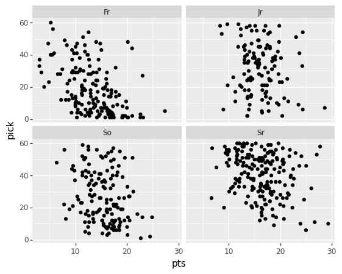

```python
# Creates a simple graph to see if there is any form of relationship
ggplot(was_drafted, aes(x='pts', y='pick'))+geom_point()+facet_wrap('yr')
```

```python
mod = smf.ols(formula = 'pick ~ pts+yr', data=was_drafted)
res = mod.fit()
print(res.summary())
```

```
                            OLS Regression Results
==============================================================================
Dep. Variable:                   pick   R-squared:                       0.306
Model:                            OLS   Adj. R-squared:                  0.302
Method:                 Least Squares   F-statistic:                     68.10
Date:                Tue, 06 Dec 2022   Prob (F-statistic):           9.67e-48
Time:                        17:35:19   Log-Likelihood:                -2536.4
No. Observations:                 622   AIC:                             5083.
Df Residuals:                     617   BIC:                             5105.
Df Model:                           4
Covariance Type:            nonrobust
==============================================================================
                 coef    std err          t      P>|t|      [0.025      0.975]
------------------------------------------------------------------------------
Intercept     33.7373      2.229     15.135      0.000      29.360      38.115
yr[T.Jr]      15.7278      1.756      8.955      0.000      12.279      19.177
yr[T.So]      10.4906      1.663      6.309      0.000       7.225      13.756
yr[T.Sr]      25.3585      1.590     15.945      0.000      22.235      28.482
pts           -1.1319      0.146     -7.735      0.000      -1.419      -0.845
==============================================================================
Omnibus:                       32.182   Durbin-Watson:                   1.949
Prob(Omnibus):                  0.000   Jarque-Bera (JB):               16.133
Skew:                           0.199   Prob(JB):                     0.000314
Kurtosis:                       2.319   Cond. No.                         68.1
==============================================================================

Notes:
[1] Standard Errors assume that the covariance matrix of the errors is correctly specified.
```

So after looking at the summary, there appears to be a small relationship between points per game in college and draft position. this might have to do with a lot of factors such as what school they play at. For example, they might play at a non power five conference school (such as Lehigh), average 30 points but get drafted 35th while a player at kansas can average 20 and be a top 5 pick. This is because we aren't taking into account variables such as strength of schedule and teammates that could dictate this average. Another factor for a player being drafted is the year they are in college. It is more impressive for a Freshman to average 20 points than a senior to average 20 points. This is why we see the Freshman average pick be lower than all of the other years for the same number of points.

```python
was_drafted.columns
```

```
Index(['GP', 'Min_per', 'Ortg', 'usg', 'eFG', 'TS_per', 'ORB_per', 'DRB_per',
       'AST_per', 'TO_per', 'FTM', 'FTA', 'FT_per', 'twoPM', 'twoPA',
       'twoP_per', 'TPM', 'TPA', 'TP_per', 'blk_per', 'stl_per', 'ftr', 'yr',
       'porpag', 'adjoe', 'pfr', 'Rec Rank', 'ast/tov', 'pick', 'drtg',
       'adrtg', 'dporpag', 'stops', 'bpm', 'obpm', 'dbpm', 'gbpm', 'mp',
       'ogbpm', 'dgbpm', 'oreb', 'dreb', 'treb', 'ast', 'stl', 'blk', 'pts',
       'was_drafted'],
      dtype='object')
```

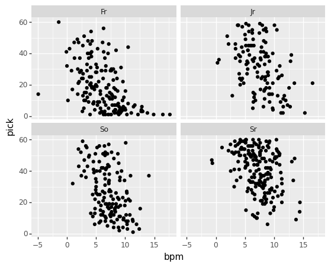

```python
# Creates a simple graph to see if there is any form of relationship between Box Plus Minus (Advanced statistics for how impactful you are) and draft position by year.
ggplot(was_drafted, aes(x='bpm', y='pick'))+geom_point()+facet_wrap('yr')
```

```python
mod = smf.ols(formula = 'pick ~ bpm+yr', data=was_drafted)
res = mod.fit()
print(res.summary())
```

```
                            OLS Regression Results
==============================================================================
Dep. Variable:                   pick   R-squared:                       0.377
Model:                            OLS   Adj. R-squared:                  0.373
Method:                 Least Squares   F-statistic:                     93.19
Date:                Tue, 06 Dec 2022   Prob (F-statistic):           5.64e-62
Time:                        17:36:03   Log-Likelihood:                -2503.1
No. Observations:                 622   AIC:                             5016.
Df Residuals:                     617   BIC:                             5038.
Df Model:                           4
Covariance Type:            nonrobust
==============================================================================
                 coef    std err          t      P>|t|      [0.025      0.975]
------------------------------------------------------------------------------
Intercept     32.4554      1.573     20.630      0.000      29.366      35.545
yr[T.Jr]      15.6728      1.640      9.559      0.000      12.453      18.893
yr[T.So]      10.2205      1.558      6.560      0.000       7.161      13.280
yr[T.Sr]      24.3935      1.459     16.721      0.000      21.529      27.258
bpm           -2.2281      0.191    -11.670      0.000      -2.603      -1.853
==============================================================================
Omnibus:                       17.708   Durbin-Watson:                   2.037
Prob(Omnibus):                  0.000   Jarque-Bera (JB):               11.122
Skew:                           0.179   Prob(JB):                      0.00384
Kurtosis:                       2.452   Cond. No.                         32.8
==============================================================================

Notes:
[1] Standard Errors assume that the covariance matrix of the errors is correctly specified.
```

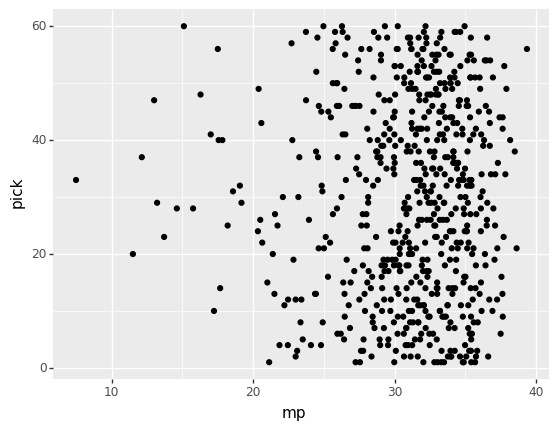

```python
# This just a simple graph to see if minutes played might have any effect on draft position
ggplot(was_drafted, aes(x='mp', y='pick'))+geom_point()#+facet_wrap('yr')
```

From doing a couple of data explorations, there appears to not be a strong correlation between your draft position and a specific statistic. I thought the more advanced statistics like box plus minus might have a correlation but overall, it appears to be very weak. I think this is because we are leaving out a lot of factors that can go into a players statistics in college. They might play for a better program like UNC where there are more talented players so they won't get as many opportunities to shine as they would at a smaller school like Davidson. There are many other factors that aren't considered as well but this was an interesting exploration. With all of these statistics combined, we can pretty accurately guess if a player will be drafted (as shwon above) but one individual statistic is not enough.

For the Next Part of The Project, I want to see if we can use college statistics to predict the impact the player will have on the NBA. This will be useful for general managers to find out what types of players can have an impact in college.

```python
nba_after_2009 = draft_info[draft_info['year']>=2009]
nba_after_2009.head()
```

|  | id | year | rank | overall_pick | team | player | college | years_active | games | minutes_played | ... | 3_point_percentage | free_throw_percentage | average_minutes_played | points_per_game | average_total_rebounds | average_assists | win_shares | win_shares_per_48_minutes | box_plus_minus | value_over_replacement |
| --- | --- | --- | --- | --- | --- | --- | --- | --- | --- | --- | --- | --- | --- | --- | --- | --- | --- | --- | --- | --- | --- |
| 1142 | 1143 | 2009 | 1 | 1 | LAC | Blake Griffin | Oklahoma | 12.0 | 724.0 | 23815.0 | ... | 0.327 | 0.696 | 32.9 | 19.8 | 8.2 | 4.1 | 79.3 | 0.160 | 3.4 | 32.5 |
| 1143 | 1144 | 2009 | 2 | 2 | MEM | Hasheem Thabeet | UConn | 5.0 | 224.0 | 2357.0 | ... | NaN | 0.578 | 10.5 | 2.2 | 2.7 | 0.1 | 4.8 | 0.099 | -2.7 | -0.4 |
| 1144 | 1145 | 2009 | 3 | 3 | OKC | James Harden | Arizona State | 13.0 | 942.0 | 32617.0 | ... | 0.361 | 0.860 | 34.6 | 24.9 | 5.6 | 6.8 | 149.6 | 0.220 | 6.8 | 72.0 |
| 1145 | 1146 | 2009 | 4 | 4 | SAC | Tyreke Evans | Memphis | 10.0 | 594.0 | 18242.0 | ... | 0.323 | 0.757 | 30.7 | 15.7 | 4.6 | 4.8 | 28.4 | 0.075 | 0.8 | 13.1 |
| 1146 | 1147 | 2009 | 5 | 5 | MIN | Ricky Rubio | NaN | 11.0 | 665.0 | 20128.0 | ... | 0.326 | 0.843 | 30.3 | 11.1 | 4.2 | 7.6 | 41.6 | 0.099 | 0.6 | 13.4 |

5 rows × 24 columns

```python
nba_win_shares = nba_after_2009[['player','win_shares_per_48_minutes']]
nba_win_shares.head()
```

|  | player | win_shares_per_48_minutes |
| --- | --- | --- |
| 1142 | Blake Griffin | 0.160 |
| 1143 | Hasheem Thabeet | 0.099 |
| 1144 | James Harden | 0.220 |
| 1145 | Tyreke Evans | 0.075 |
| 1146 | Ricky Rubio | 0.099 |

```python
was_drafted = pd.read_csv("CollegeBasketballPlayers2009-2021.csv")
was_drafted["was_drafted"] = was_drafted.apply(lambda x: wasPicked2(x["pick"], x['player_name'], x['year']), axis=1)
was_drafted = was_drafted.drop(['Unnamed: 64', 'Unnamed: 65', 'team', 'conf', 'ht','num', 'type', 'year', 'pid', 'rimmade','rimmade+rimmiss',
                                   'midmade','midmade+midmiss','rimmade/(rimmade+rimmiss)', 'midmade/(midmade+midmiss)',
                                    'dunksmade','dunksmiss+dunksmade', 'dunksmade/(dunksmade+dunksmiss)'], axis=1)
was_drafted = was_drafted[was_drafted['was_drafted'] == True]
college_and_nba_stats = pd.merge(was_drafted, nba_win_shares,  left_on="player_name", right_on='player')
college_and_nba_stats.head()
```

|  | player_name | GP | Min_per | Ortg | usg | eFG | TS_per | ORB_per | DRB_per | AST_per | ... | oreb | dreb | treb | ast | stl | blk | pts | was_drafted | player | win_shares_per_48_minutes |
| --- | --- | --- | --- | --- | --- | --- | --- | --- | --- | --- | --- | --- | --- | --- | --- | --- | --- | --- | --- | --- | --- |
| 0 | Chase Budinger | 35 | 93.7 | 117.5 | 23.9 | 55.4 | 59.42 | 4.9 | 14.8 | 19.0 | ... | 1.4000 | 4.8000 | 6.2000 | 3.3714 | 1.4286 | 0.4571 | 18.0000 | True | Chase Budinger | 0.083 |
| 1 | Eric Maynor | 34 | 88.0 | 117.3 | 32.6 | 52.4 | 58.33 | 1.6 | 10.0 | 40.8 | ... | 0.4706 | 3.1176 | 3.5882 | 6.1765 | 1.7059 | 0.1765 | 22.3529 | True | Eric Maynor | 0.041 |
| 2 | Earl Clark | 37 | 85.4 | 100.3 | 24.6 | 49.2 | 51.67 | 9.1 | 18.7 | 18.2 | ... | 2.7568 | 5.9459 | 8.7027 | 3.2162 | 1.0270 | 1.3784 | 14.1892 | True | Earl Clark | 0.038 |
| 3 | Dante Cunningham | 38 | 78.6 | 109.0 | 24.7 | 52.5 | 55.68 | 9.5 | 17.0 | 8.8 | ... | 2.6053 | 4.8684 | 7.4737 | 1.2368 | 1.2368 | 1.2368 | 16.1053 | True | Dante Cunningham | 0.080 |
| 4 | Jermaine Taylor | 30 | 79.8 | 112.9 | 36.1 | 55.1 | 58.60 | 7.2 | 12.1 | 17.3 | ... | 1.9000 | 3.3000 | 5.2000 | 1.8000 | 1.2333 | 0.7333 | 26.0333 | True | Jermaine Taylor | 0.014 |

5 rows × 51 columns

```python
#college_and_nba_stats = college_and_nba_stats.drop(['player_name','player', 'was_drafted', 'yr'], axis=1)
#college_and_nba_stats = college_and_nba_stats.drop([ 'yr'], axis=1)
college_and_nba_stats = college_and_nba_stats.dropna(how='all')
college_and_nba_stats = college_and_nba_stats.dropna(subset=['win_shares_per_48_minutes'])
college_and_nba_stats.columns
```

[output not shown]

```python
# Creates the data split needed for a random forest
from sklearn.decomposition import PCA
y = college_and_nba_stats['win_shares_per_48_minutes']
X = college_and_nba_stats.drop('win_shares_per_48_minutes', axis=1)
X.fillna(X.mean(), inplace=True)
X_train, X_test, y_train, y_test = train_test_split(X, y, test_size = 0.1,random_state = 90)
```

```python
from sklearn.ensemble import RandomForestRegressor
RF = RandomForestRegressor()
scores = cross_val_score(RF, X, y, cv=10, error_score='raise')
scores
```

```
array([-0.01170349,  0.08244399,  0.14167374,  0.3245011 , -0.0959618 ,
       -0.01510888,  0.16723235,  0.20889164, -0.28304072,  0.12407505])
```

```python
RF1 = RandomForestRegressor()
RF1.fit(X_train, y_train)
RF1.score(X_test, y_test)
```

```
-0.175833960592505
```

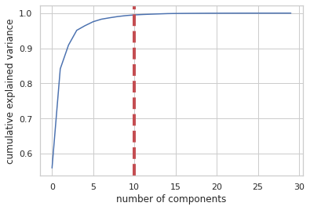

```
None
```

|  | Cumulative Variance Ratio | Explained Variance Ratio |
| --- | --- | --- |
| 0 | 0.558942 | 0.558942 |
| 1 | 0.841330 | 0.282388 |
| 2 | 0.908938 | 0.067609 |
| 3 | 0.951031 | 0.042092 |
| 4 | 0.964233 | 0.013202 |
| 5 | 0.975624 | 0.011391 |
| 6 | 0.982732 | 0.007108 |
| 7 | 0.986757 | 0.004025 |
| 8 | 0.990341 | 0.003584 |
| 9 | 0.992985 | 0.002644 |

```python
import matplotlib.pyplot as plt
import seaborn as sns
from sklearn.decomposition import PCA
pca_test = PCA(n_components=30)
pca_test.fit(X)
sns.set(style='whitegrid')
plt.plot(np.cumsum(pca_test.explained_variance_ratio_))
plt.xlabel('number of components')
plt.ylabel('cumulative explained variance')
plt.axvline(linewidth=4, color='r', linestyle = '--', x=10, ymin=0, ymax=1)
display(plt.show())
evr = pca_test.explained_variance_ratio_
cvr = np.cumsum(pca_test.explained_variance_ratio_)
pca_df = pd.DataFrame()
pca_df['Cumulative Variance Ratio'] = cvr
pca_df['Explained Variance Ratio'] = evr
display(pca_df.head(10))
```

```python
y = college_and_nba_stats['win_shares_per_48_minutes']
X = college_and_nba_stats.drop('win_shares_per_48_minutes', axis=1)
X.fillna(X.mean(), inplace=True)
pca = PCA(n_components=10)
pca.fit(X)
X_train, X_test, y_train, y_test = train_test_split(X, y, test_size = 0.1,random_state = 90)
X_train_pca = pca.transform(X_train)
X_test_pca = pca.transform(X_test)
```

```python
RF = RandomForestRegressor()
RF.fit(X_train_pca, y_train)
RF.score(X_test_pca, y_test)
```

```
-0.04402375102261047
```